# Análise de Dados para CosmeticCo

Pedro Hagge Baptista

2024-08-10

# Introdução

Este documento apresenta uma análise detalhada dos dados de vendas, estoque e desempenho dos vendedores da CosmeticCo. Utilizando ferramentas estatísticas e visuais, nosso objetivo é extrair insights que otimizem as operações e melhorem a eficiência das vendas.

# 1. Carregamento e Preparação dos Dados

## Carregamento dos Dados

```r
# Carregar os conjuntos de dados
ano_2021 <- read.csv("/home/rstudio/datasets/2021.csv")
store_final <- read.csv("/home/rstudio/datasets/store_final.csv")
target_store_final <- read.csv("/home/rstudio/datasets/target_store_final.csv")
sku_status_dataset <- read.csv2("/home/rstudio/datasets/sku_status_dataset.csv")
targets_salesperson_final <- read.csv("/home/rstudio/datasets/targets_salesperson_final.csv")
sku_price <- read.csv("/home/rstudio/datasets/sku_price.csv")
sku_dataset <- read.csv2("/home/rstudio/datasets/sku_dataset.csv")
sku_cost <- read.csv("/home/rstudio/datasets/sku_cost.csv")
employee_final <- read.csv("/home/rstudio/datasets/employee_final.csv")
```

## Visualização das Primeiras Linhas

```r
# Mostrar as primeiras linhas de cada conjunto de dados para uma verificação inicial
head(ano_2021)
```

```
##         data cod_vendedor          cod_loja cod_transacao quantidade
## 1 2021-02-24          578 SP Capital Sul_19    00027cd5b0          4
## 2 2021-02-26           65             RS_25    00030e5a2a          5
## 3 2021-02-20          310             SC_39    0003605b83          2
## 4 2021-02-26          885    SP Interior_64    000463b858          1
## 5 2021-02-26          885    SP Interior_64    000463b858          4
## 6 2021-02-20           46              RS_4    0004fba130          3
##       cod_prod     preco
## 1 773303979204 265.51935
## 2 543067056967 378.00270
## 3 918776970598 162.26592
## 4 268539633476  85.74331
## 5 309763107859 132.74123
## 6 635498338153 946.01642
```

```r
head(store_final)
```

```
##           nome_loja         regiao diretoria data_inauguracao
## 1 SP Capital Sul_59 SP Capital Sul Grande SP       09/08/2020
## 2 SP Capital Sul_30 SP Capital Sul Grande SP       05/03/2000
## 3 SP Capital Sul_17 SP Capital Sul Grande SP       28/02/2019
## 4  SP Capital Sul_9 SP Capital Sul Grande SP       16/05/2001
## 5 SP Capital Sul_97 SP Capital Sul Grande SP       12/07/2017
## 6 SP Capital Sul_90 SP Capital Sul Grande SP       15/04/2000
```

```r
head(target_store_final)
```

```
##     month store_id sales_target
## 1 01/2000    MG_21       116070
## 2 01/2000    MG_23       102199
## 3 01/2000    MG_24        98628
## 4 01/2000    MG_26       113215
## 5 01/2000    MG_29       113450
## 6 01/2000    MG_34       116066
```

```r
head(sku_status_dataset)
```

```
##       cod_prod data_inicio   data_fim
## 1 603078352615  2007-08-02 2023-09-16
## 2 131384024501  2006-08-22 2020-05-12
## 3  85873708529  2000-03-05
## 4 579926605113  2011-05-05 2018-06-23
## 5 397769055946  2006-07-15
## 6 981647487600  2021-04-02
```

```r
head(targets_salesperson_final)
```

```
##   id_employee sales_target   month
## 1         643        25088 01/2000
## 2         643        39703 02/2000
## 3         643        23478 03/2000
## 4         643        22417 04/2000
## 5         643        25622 05/2000
## 6         643        32298 06/2000
```

```r
head(sku_price)
```

```
##       cod_prod data_inicio   data_fim preco
## 1 603078352615  2007-08-02 2009-08-07 25.99
## 2 603078352615  2009-08-08 2011-08-14 26.99
## 3 603078352615  2011-08-15 2013-08-20 27.99
## 4 603078352615  2013-08-21 2015-08-27 27.99
## 5 603078352615  2015-08-28 2017-09-02 28.99
## 6 603078352615  2017-09-03 2019-09-09 29.99
```

```r
head(sku_dataset)
```

```
##       cod_prod                      nome_abrev
## 1 603078352615    Acne Solutions Cleansing Bar
## 2 131384024501              Pep Start Daily UV
## 3  85873708529          Deep Comfort Body Wash
## 4 579926605113     Lipikar Wash Gentle Foaming
## 5 397769055946 Anthelios AOX Daily Antioxidant
## 6 981647487600            Basil White Tea Body
##                                        nome_completo
## 1       Acne Solutions Cleansing Bar for Face & Body
## 2 Pep Start Daily UV Protector Broad Spectrum SPF 50
## 3                             Deep Comfort Body Wash
## 4  Lipikar Wash AP+ Gentle Foaming Moisturizing Wash
## 5  Anthelios AOX Daily Antioxidant Face Serum SPF 50
## 6                        Basil & White Tea Body Wash
##                                                                                       descricao
## 1            Sabonete líquido Clinique Acne Solutions Cleansing Bar for Face & Body  para Corpo
## 2        Protetor solar Clinique Pep Start Daily UV Protector Broad Spectrum SPF 50  para Corpo
## 3                                  Sabonete líquido Clinique Deep Comfort Body Wash  para Corpo
## 4 Sabonete líquido La Roche-Posay Lipikar Wash AP+ Gentle Foaming Moisturizing Wash  para Corpo
## 5   Protetor solar La Roche-Posay Anthelios AOX Daily Antioxidant Face Serum SPF 50  para Corpo
## 6                                Sabonete líquido Nivea Basil & White Tea Body Wash  para Corpo
##   categoria    sub_categoria          marca conteudo_valor conteudo_medida
## 1     Corpo Sabonete líquido       Clinique          156.0              ml
## 2     Corpo   Protetor solar       Clinique           30.0              ml
## 3     Corpo Sabonete líquido       Clinique          204.0              ml
## 4     Corpo Sabonete líquido La Roche-Posay          405.0              ml
## 5     Corpo   Protetor solar La Roche-Posay           30.0              ml
## 6     Corpo Sabonete líquido          Nivea          600.0              ml
```

```r
head(sku_cost)
```

```
##       cod_prod data_inicio   data_fim custo
## 1 603078352615  2007-08-02 2011-08-13 26.25
## 2 603078352615  2011-08-14 2015-08-25 27.14
## 3 603078352615  2015-08-26 2019-09-06 27.54
## 4 603078352615  2019-09-07 2023-09-16 27.62
## 5 131384024501  2006-08-22 2009-05-20 70.80
## 6 131384024501  2009-05-21 2012-02-17 71.63
```

```r
head(employee_final)
```

```
##   id_employee           name surname            cpf status     role
## 1         643      Antonella da Cruz 938.507.461-00  ativo  gerente
## 2         924 Carlos Eduardo   Alves 501.639.827-59  ativo vendedor
## 3         567     Ana Sophia   Ramos 980.413.526-42  ativo vendedor
## 4         660        Marcela   Brito 859.163.742-91  ativo vendedor
## 5         297       Leonardo   Porto 652.341.890-15  ativo vendedor
## 6         523         Heitor   Sales 472.395.061-34  ativo vendedor
##   initial_date end_date store_id
## 1   14/12/2007             MG_21
## 2   29/09/2014             MG_21
## 3   03/04/2006             MG_21
## 4   14/03/2003             MG_21
## 5   27/06/2021             MG_23
## 6   11/09/2021             MG_23
```

## Verificação da Estrutura dos Dados

```r
# Verificar a estrutura dos conjuntos de dados para entender os tipos de dados e valores ausentes
str(ano_2021)
```

```
## 'data.frame':    3022584 obs. of  7 variables:
##  $ data         : chr  "2021-02-24" "2021-02-26" "2021-02-20" "2021-02-26" ...
##  $ cod_vendedor : int  578 65 310 885 885 46 613 613 613 173 ...
##  $ cod_loja     : chr  "SP Capital Sul_19" "RS_25" "SC_39" "SP Interior_64" ...
##  $ cod_transacao: chr  "00027cd5b0" "00030e5a2a" "0003605b83" "000463b858" ...
##  $ quantidade   : int  4 5 2 1 4 3 5 5 5 4 ...
##  $ cod_prod     : num  7.73e+11 5.43e+11 9.19e+11 2.69e+11 3.10e+11 ...
##  $ preco        : num  265.5 378 162.3 85.7 132.7 ...
```

```r
str(store_final)
```

```
## 'data.frame':    205 obs. of  4 variables:
##  $ nome_loja       : chr  "SP Capital Sul_59" "SP Capital Sul_30" "SP Capital Sul_17" "SP Capital Sul_9" ...
##  $ regiao          : chr  "SP Capital Sul" "SP Capital Sul" "SP Capital Sul" "SP Capital Sul" ...
##  $ diretoria       : chr  "Grande SP" "Grande SP" "Grande SP" "Grande SP" ...
##  $ data_inauguracao: chr  "09/08/2020" "05/03/2000" "28/02/2019" "16/05/2001" ...
```

```r
str(target_store_final)
```

```
## 'data.frame':    61500 obs. of  3 variables:
##  $ month       : chr  "01/2000" "01/2000" "01/2000" "01/2000" ...
##  $ store_id    : chr  "MG_21" "MG_23" "MG_24" "MG_26" ...
##  $ sales_target: int  116070 102199 98628 113215 113450 116066 133941 116652 110423 134822 ...
```

```r
str(sku_status_dataset)
```

```
## 'data.frame':    563 obs. of  3 variables:
##  $ cod_prod   : num  6.03e+11 1.31e+11 8.59e+10 5.80e+11 3.98e+11 ...
##  $ data_inicio: chr  "2007-08-02" "2006-08-22" "2000-03-05" "2011-05-05" ...
##  $ data_fim   : chr  "2023-09-16" "2020-05-12" "" "2018-06-23" ...
```

```r
str(targets_salesperson_final)
```

```
## 'data.frame':    246000 obs. of  3 variables:
##  $ id_employee : int  643 643 643 643 643 643 643 643 643 643 ...
##  $ sales_target: int  25088 39703 23478 22417 25622 32298 37406 26462 21400 35700 ...
##  $ month       : chr  "01/2000" "02/2000" "03/2000" "04/2000" ...
```

```r
str(sku_price)
```

```
## 'data.frame':    5323 obs. of  4 variables:
##  $ cod_prod   : num  6.03e+11 6.03e+11 6.03e+11 6.03e+11 6.03e+11 ...
##  $ data_inicio: chr  "2007-08-02" "2009-08-08" "2011-08-15" "2013-08-21" ...
##  $ data_fim   : chr  "2009-08-07" "2011-08-14" "2013-08-20" "2015-08-27" ...
##  $ preco      : num  26 27 28 28 29 ...
```

```r
str(sku_dataset)
```

```
## 'data.frame':    563 obs. of  9 variables:
##  $ cod_prod       : num  6.03e+11 1.31e+11 8.59e+10 5.80e+11 3.98e+11 ...
##  $ nome_abrev     : chr  "Acne Solutions Cleansing Bar" "Pep Start Daily UV" "Deep Comfort Body Wash" "Lipikar Wash Gentle Foaming" ...
##  $ nome_completo  : chr  "Acne Solutions Cleansing Bar for Face & Body" "Pep Start Daily UV Protector Broad Spectrum SPF 50" "Deep Comfort Body Wash" "Lipikar Wash AP+ Gentle Foaming Moisturizing Wash" ...
##  $ descricao      : chr  "Sabonete líquido Clinique Acne Solutions Cleansing Bar for Face & Body  para Corpo" "Protetor solar Clinique Pep Start Daily UV Protector Broad Spectrum SPF 50  para Corpo" "Sabonete líquido Clinique Deep Comfort Body Wash  para Corpo" "Sabonete líquido La Roche-Posay Li…
##  $ categoria      : chr  "Corpo" "Corpo" "Corpo" "Corpo" ...
##  $ sub_categoria  : chr  "Sabonete líquido" "Protetor solar" "Sabonete líquido" "Sabonete líquido" ...
##  $ marca          : chr  "Clinique" "Clinique" "Clinique" "La Roche-Posay" ...
##  $ conteudo_valor : chr  "156.0" "30.0" "204.0" "405.0" ...
##  $ conteudo_medida: chr  "ml" "ml" "ml" "ml" ...
```

```r
str(sku_cost)
```

```
## 'data.frame':    2235 obs. of  4 variables:
##  $ cod_prod   : num  6.03e+11 6.03e+11 6.03e+11 6.03e+11 1.31e+11 ...
##  $ data_inicio: chr  "2007-08-02" "2011-08-14" "2015-08-26" "2019-09-07" ...
##  $ data_fim   : chr  "2011-08-13" "2015-08-25" "2019-09-06" "2023-09-16" ...
##  $ custo      : num  26.2 27.1 27.5 27.6 70.8 ...
```

```r
str(employee_final)
```

```
## 'data.frame':    920 obs. of  9 variables:
##  $ id_employee : int  643 924 567 660 297 523 264 834 693 417 ...
##  $ name        : chr  "Antonella" "Carlos Eduardo" "Ana Sophia" "Marcela" ...
##  $ surname     : chr  "da Cruz" "Alves" "Ramos" "Brito" ...
##  $ cpf         : chr  "938.507.461-00" "501.639.827-59" "980.413.526-42" "859.163.742-91" ...
##  $ status      : chr  "ativo" "ativo" "ativo" "ativo" ...
##  $ role        : chr  "gerente" "vendedor" "vendedor" "vendedor" ...
##  $ initial_date: chr  "14/12/2007" "29/09/2014" "03/04/2006" "14/03/2003" ...
##  $ end_date    : chr  "" "" "" "" ...
##  $ store_id    : chr  "MG_21" "MG_21" "MG_21" "MG_21" ...
```

# 2. Resumo Estatístico e Descrição dos Dados

## Resumo Estatístico

```r
# Obter um resumo estatístico para entender distribuições, médias e outliers
summary(ano_2021)
```

```
##      data            cod_vendedor      cod_loja         cod_transacao
##  Length:3022584     Min.   :   2.0   Length:3022584     Length:3022584
##  Class :character   1st Qu.: 251.0   Class :character   Class :character
##  Mode  :character   Median : 496.0   Mode  :character   Mode  :character
##                     Mean   : 499.5
##                     3rd Qu.: 757.0
##                     Max.   :1000.0
##    quantidade       cod_prod             preco
##  Min.   :1.000   Min.   :8.312e+09   Min.   :   9.211
##  1st Qu.:2.000   1st Qu.:2.607e+11   1st Qu.: 103.225
##  Median :4.000   Median :5.431e+11   Median : 200.114
##  Mean   :3.581   Mean   :5.191e+11   Mean   : 352.300
##  3rd Qu.:5.000   3rd Qu.:7.857e+11   3rd Qu.: 379.856
##  Max.   :8.000   Max.   :9.970e+11   Max.   :4411.540
```

```r
summary(store_final)
```

```
##   nome_loja            regiao           diretoria         data_inauguracao
##  Length:205         Length:205         Length:205         Length:205
##  Class :character   Class :character   Class :character   Class :character
##  Mode  :character   Mode  :character   Mode  :character   Mode  :character
```

```r
summary(target_store_final)
```

```
##     month             store_id          sales_target
##  Length:61500       Length:61500       Min.   : 83260
##  Class :character   Class :character   1st Qu.:111964
##  Mode  :character   Mode  :character   Median :120030
##                                        Mean   :120061
##                                        3rd Qu.:128116
##                                        Max.   :157485
```

```r
summary(sku_status_dataset)
```

```
##     cod_prod         data_inicio          data_fim
##  Min.   :6.587e+09   Length:563         Length:563
##  1st Qu.:2.506e+11   Class :character   Class :character
##  Median :4.800e+11   Mode  :character   Mode  :character
##  Mean   :5.024e+11
##  3rd Qu.:7.696e+11
##  Max.   :9.970e+11
```

```r
summary(targets_salesperson_final)
```

```
##   id_employee      sales_target      month
##  Min.   :   1.0   Min.   :20000   Length:246000
##  1st Qu.: 249.8   1st Qu.:25014   Class :character
##  Median : 490.5   Median :30047   Mode  :character
##  Mean   : 497.6   Mean   :30015
##  3rd Qu.: 752.2   3rd Qu.:35000
##  Max.   :1000.0   Max.   :40000
```

```r
summary(sku_price)
```

```
##     cod_prod         data_inicio          data_fim             preco
##  Min.   :6.587e+09   Length:5323        Length:5323        Min.   :  9.99
##  1st Qu.:2.504e+11   Class :character   Class :character   1st Qu.: 35.99
##  Median :4.952e+11   Mode  :character   Mode  :character   Median : 57.99
##  Mean   :5.038e+11                                         Mean   : 93.55
##  3rd Qu.:7.719e+11                                         3rd Qu.: 94.99
##  Max.   :9.970e+11                                         Max.   :550.99
```

```r
summary(sku_dataset)
```

```
##     cod_prod          nome_abrev        nome_completo       descricao
##  Min.   :6.587e+09   Length:563         Length:563         Length:563
##  1st Qu.:2.506e+11   Class :character   Class :character   Class :character
##  Median :4.800e+11   Mode  :character   Mode  :character   Mode  :character
##  Mean   :5.024e+11
##  3rd Qu.:7.696e+11
##  Max.   :9.970e+11
##   categoria         sub_categoria         marca           conteudo_valor
##  Length:563         Length:563         Length:563         Length:563
##  Class :character   Class :character   Class :character   Class :character
##  Mode  :character   Mode  :character   Mode  :character   Mode  :character
##
##
##
##  conteudo_medida
##  Length:563
##  Class :character
##  Mode  :character
##
##
##
```

```r
summary(sku_cost)
```

```
##     cod_prod         data_inicio          data_fim             custo
##  Min.   :6.587e+09   Length:2235        Length:2235        Min.   :  6.35
##  1st Qu.:2.472e+11   Class :character   Class :character   1st Qu.: 22.89
##  Median :4.797e+11   Mode  :character   Mode  :character   Median : 33.96
##  Mean   :4.983e+11                                         Mean   : 68.34
##  3rd Qu.:7.689e+11                                         3rd Qu.: 64.93
##  Max.   :9.970e+11                                         Max.   :414.07
```

```r
summary(employee_final)
```

```
##   id_employee         name             surname              cpf
##  Min.   :   1.0   Length:920         Length:920         Length:920
##  1st Qu.: 248.8   Class :character   Class :character   Class :character
##  Median : 492.5   Mode  :character   Mode  :character   Mode  :character
##  Mean   : 497.5
##  3rd Qu.: 750.2
##  Max.   :1000.0
##     status              role           initial_date         end_date
##  Length:920         Length:920         Length:920         Length:920
##  Class :character   Class :character   Class :character   Class :character
##  Mode  :character   Mode  :character   Mode  :character   Mode  :character
##
##
##
##    store_id
##  Length:920
##  Class :character
##  Mode  :character
##
##
##
```

## Descrição das Variáveis

As variáveis contidas nos conjuntos de dados incluem dados de transação, informações do produto, detalhes de custos, preços, e dados demográficos de empregados, como ilustrado nas descrições acima.

### Tabela: `ano_2021`

| Coluna | Tipo | Descrição |
| --- | --- | --- |
| data | character | Data da transação |
| cod_vendedor | numérico | Código identificador do vendedor |
| cod_loja | character | Código identificador da loja |
| cod_transacao | character | Código identificador da transação |
| quantidade | numérico | Quantidade de itens vendidos |
| cod_prod | numérico | Código identificador do produto |
| preco | numérico | Preço do produto |

### Tabela: `store_final`

| Coluna | Tipo | Descrição |
| --- | --- | --- |
| nome_loja | character | Nome da loja |
| regiao | character | Região onde a loja está localizada |
| diretoria | character | Diretoria responsável pela loja |
| data_inauguracao | character | Data de inauguração da loja |

### Tabela: `target_store_final`

| Coluna | Tipo | Descrição |
| --- | --- | --- |
| month | character | Mês da meta de vendas |
| store_id | character | Código identificador da loja |
| sales_target | numérico | Meta de vendas para a loja |

### Tabela: `sku_status_dataset`

| Coluna | Tipo | Descrição |
| --- | --- | --- |
| cod_prod | numérico | Código identificador do produto |
| data_inicio | character | Data de início da validade do status do produto |
| data_fim | character | Data de fim da validade do status do produto |

### Tabela: `targets_salesperson_final`

| Coluna | Tipo | Descrição |
| --- | --- | --- |
| id_employee | numérico | Código identificador do funcionário |
| sales_target | numérico | Meta de vendas para o funcionário |
| month | character | Mês da meta de vendas |

### Tabela: `sku_price`

| Coluna | Tipo | Descrição |
| --- | --- | --- |
| cod_prod | numérico | Código identificador do produto |
| data_inicio | character | Data de início da validade do preço do produto |
| data_fim | character | Data de fim da validade do preço do produto |
| preco | numérico | Preço do produto |

### Tabela: `sku_dataset`

| Coluna | Tipo | Descrição |
| --- | --- | --- |
| cod_prod | numérico | Código identificador do produto |
| nome_abrev | character | Nome abreviado do produto |
| nome_completo | character | Nome completo do produto |
| descricao | character | Descrição do produto |
| categoria | character | Categoria do produto |
| sub_categoria | character | Subcategoria do produto |
| marca | character | Marca do produto |
| conteudo_valor | character | Valor do conteúdo do produto |
| conteudo_medida | character | Medida do conteúdo do produto |

### Tabela: `sku_cost`

| Coluna | Tipo | Descrição |
| --- | --- | --- |
| cod_prod | numérico | Código identificador do produto |
| data_inicio | character | Data de início da validade do custo do produto |
| data_fim | character | Data de fim da validade do custo do produto |
| custo | numérico | Custo do produto |

### Tabela: `employee_final`

| Coluna | Tipo | Descrição |
| --- | --- | --- |
| id_employee | numérico | Código identificador do funcionário |
| name | character | Nome do funcionário |
| surname | character | Sobrenome do funcionário |
| cpf | character | CPF do funcionário |
| status | character | Status do funcionário (ativo/inativo) |
| role | character | Função/cargo do funcionário |
| initial_date | character | Data de início do contrato do funcionário |
| end_date | character | Data de término do contrato do funcionário |
| store_id | character | Código identificador da loja onde o funcionário trabalha |

# 3. Análise Univariada

## Visualização das Distribuições

Este segmento explora a distribuição individual de variáveis chave, como as metas de vendas e os custos dos produtos. Histogramas e gráficos de densidade são utilizados para visualizar como essas variáveis estão distribuídas, o que pode ajudar a identificar padrões ou necessidades de ajuste em estratégias de precificação ou estoque.

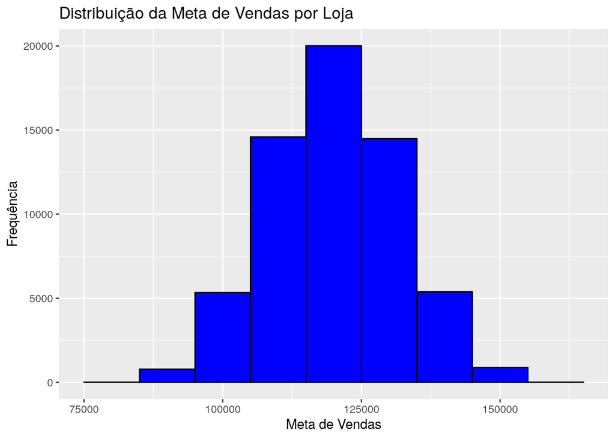

```r
# Histograma para 'sales_target' de 'target_store_final' para ver a distribuição das metas de vendas nas lojas
ggplot(target_store_final, aes(x = sales_target)) +
  geom_histogram(binwidth = 10000, fill = "blue", color = "black") +
  labs(title = "Distribuição da Meta de Vendas por Loja", x = "Meta de Vendas", y = "Frequência")
```

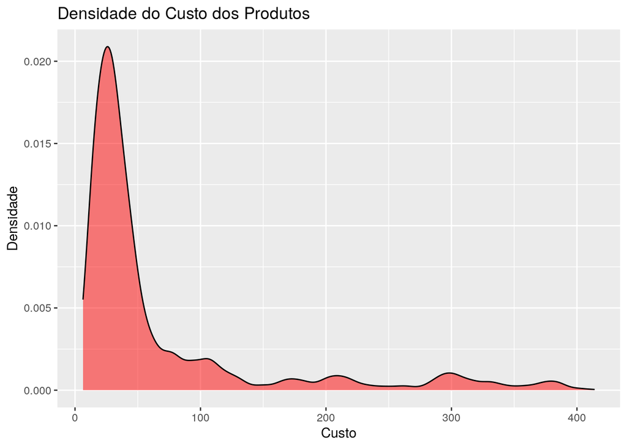

```r
# Gráfico de densidade para 'custo' de 'sku_cost' para avaliar a distribuição de custos dos produtos
ggplot(sku_cost, aes(x = custo)) +
  geom_density(fill = "red", alpha = 0.5) +
  labs(title = "Densidade do Custo dos Produtos", x = "Custo", y = "Densidade")
```

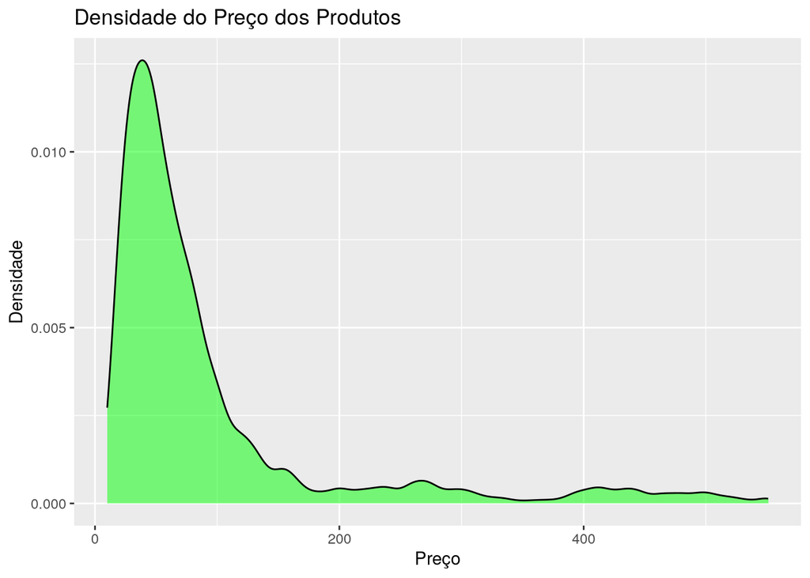

```r
# Gráfico de densidade para 'preco' de 'sku_price' para avaliar a distribuição de preços dos produtos
ggplot(sku_price, aes(x = preco)) +
  geom_density(fill = "green", alpha = 0.5) +
  labs(title = "Densidade do Preço dos Produtos", x = "Preço", y = "Densidade")
```

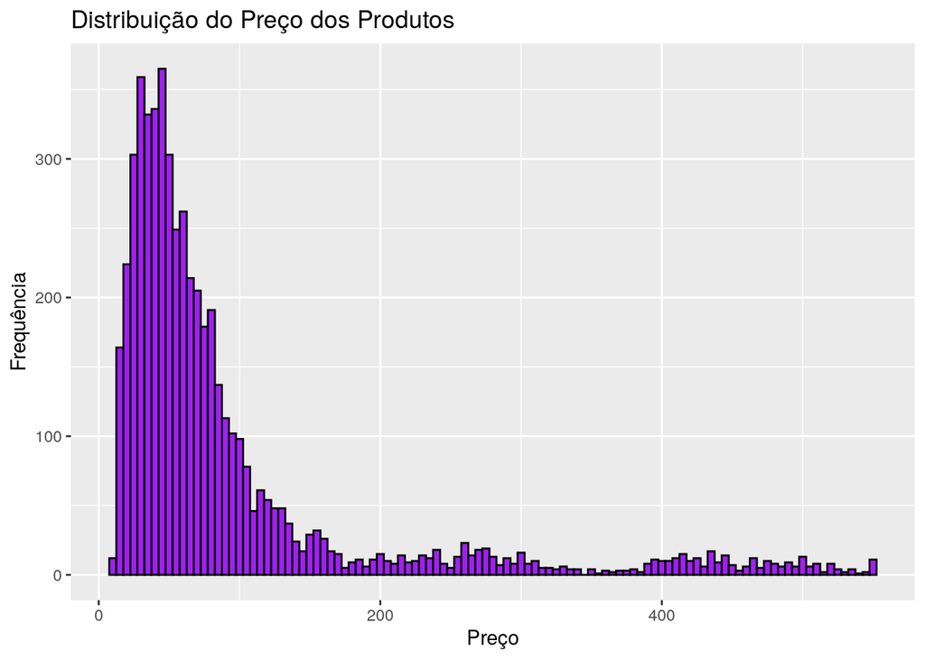

```r
# Histograma para 'preco' de 'sku_price' para ver a distribuição dos preços dos produtos
ggplot(sku_price, aes(x = preco)) +
  geom_histogram(binwidth = 5, fill = "purple", color = "black") +
  labs(title = "Distribuição do Preço dos Produtos", x = "Preço", y = "Frequência")
```